# Lecture #25: Linear Regression, Revisited

STAT 200 – Introductory Statistics

Torin Quinlivan

tquinlivan@knox.edu

Knox College

February 25, 2026

## Example #1: Violent Crime Rate in 1990 vs. 2000

Understanding the persistence of violent crime in cities can help determine which cities are being successful in reducing it and which cities are not. What is the relationship between the violent crime rate in 1990 and in 2000?

Note that we want to know *more* than just if there is a significant relationship. We want to:

- Specify how much one influences the other.
- Estimate violent crime rates in 2000, given the value in 1990.
- Predict violent crime rates in 2000, given the value in 1990.

## Example #1: Violent Crime Rate in 1990 vs. 2000

What is the relationship between these two variables?

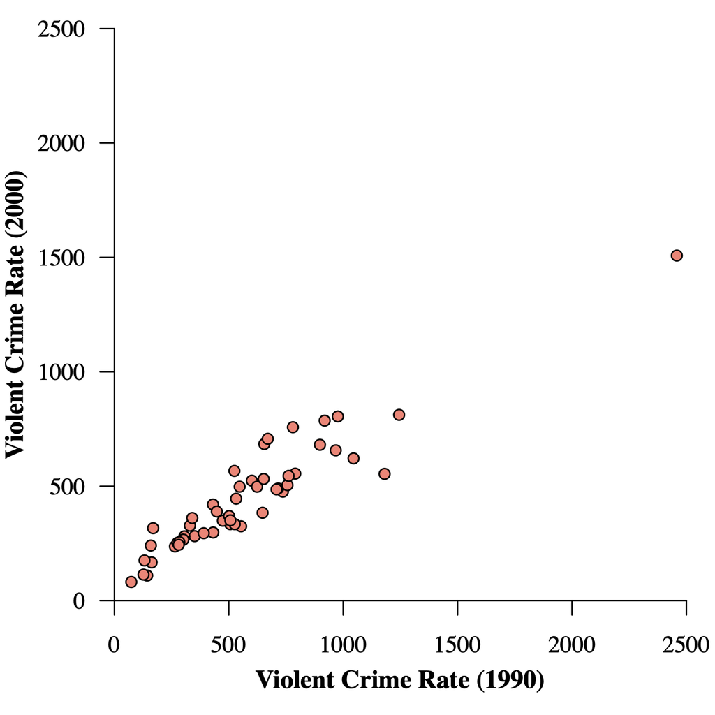

## The Theory

To summarize the relationship, we use a “line of best fit”:

$$\hat{y} = \beta_0 + \beta_1 x$$

However, this raises the following question: What do we mean by the “best” fit?

## The Theory

This is the most important question we can answer. Different answers lead to different fitting methods.

MATH/STAT 225 covers a few of the different methods. (There’s always slots open in the winter term! Dr. Forsberg would love to have you!) It also covers the easiest method in great detail.

In this course, we will only look at the easiest method: ordinary least squares (OLS).

It is based on minimizing the sum of the squared residual values.

## The Theory: The Line

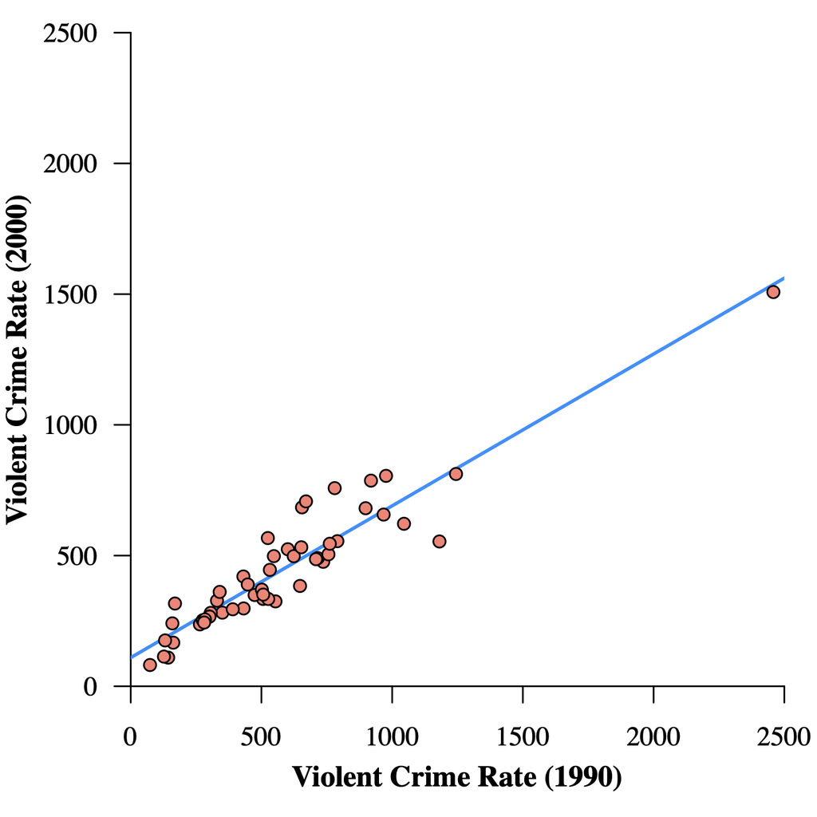

## The Theory: The Residuals

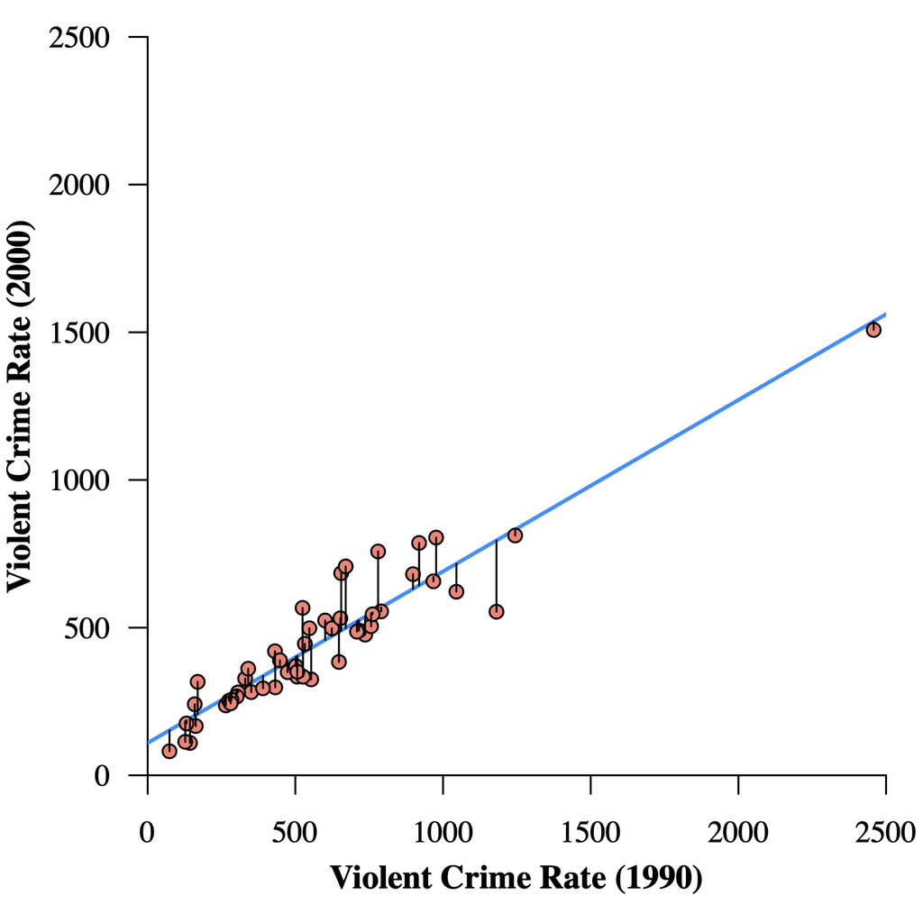

## The Theory

Thus, our estimators of the $y$-intercept and slope (effect) are:

$$\begin{aligned}
b_0 &= \overline{y} - b_1 \overline{x} \\
b_1 &= \frac{\sum x_i y_i - n \overline{x} \overline{y}}{\sum x_i^2 - n \overline{x}^2}
\end{aligned}$$

## The Theory

By the way, the second formula can also be written as:

$$\begin{aligned}
b_1 &= \frac{\sum (x_i - \overline{x}) (y_i - \overline{y})}{\sum (x_i - \overline{x})^2} \\
&= r \left( \frac{s_y}{s_x} \right)
\end{aligned}$$

This gives some insight into the slope, the correlation, and the relationship between them.

## The Theory: Slope

It can be shown that the slope estimate has the following distribution:

$$b_1 \sim Normal \left( \beta_1, \frac{\sigma_e^2}{\sum (x_i - \overline{x})^2} \right)$$

With this distribution, we are able to formulate confidence intervals and $p$-values for hypotheses about the slope (the effect of $x$ on $y$).

## The Theory: Slope

The proof of this is rather elementary and follows from the assumptions we make on the residuals. The three-line proof is provided in STAT 225. Also in that course is the proof of the confidence intervals and the $p$-values based on this distribution. (These are also three-line proofs.)

**Note:** Here, $\sigma_e^2$ is the population variance of the residuals.

## The Theory: ANOVA

Sometimes, we want to draw conclusions about *the model, as a whole.*

To do this, we rely on ANOVA (does the model give information about the dependent variable?). As such, we need to calculate the following variations:

| $SSM = \displaystyle\sum_i (\hat{y}_i - \overline{y})^2$ | Explained by Model |
| --- | --- |
| $SSE = \displaystyle\sum_i (y_i - \hat{y}_i)^2$ | Remaining Error |
| $SST = \displaystyle\sum_i (y_i - \overline{y})^2$ | Total |

## The Theory: ANOVA

The ANOVA table for the linear regression model with 1 independent variable:

| Source | $\boldsymbol{SS}$ | $\boldsymbol{df}$ | $\boldsymbol{MS}$ | $\boldsymbol{F}$ | $\boldsymbol{p}$ |
| --- | --- | --- | --- | --- | --- |
| Model | $\displaystyle\sum_i (\hat{y}_i - \overline{y})^2$ | $1$ | $\dfrac{SSM}{1}$ | $\dfrac{MSM}{MSE}$ | $\mathbb{P}(F \ge f)$ |
| Error | $\displaystyle\sum_i (y_i - \hat{y}_i)^2$ | $n - 2$ | $\dfrac{SSE}{n-2}$ |  |  |
| Total | $\displaystyle\sum_i (y_i - \overline{y})^2$ | $n - 1$ |  |  |  |

The ANOVA table is useful for drawing conclusions about the model *as a whole*.

## The Theory: ANOVA

and:

$$R^2 = r^2$$

Here, $r$ is the correlation we learned about in the past.

## The Theory: `R`

- The first step is to fit the model.
- The second step is to summarize the results.

## Returning to Example #1

This is the code to start to answer the questions raised at the start of this section:

```r
# Load and attach the data
dt = read.csv("crime.csv")
attach(dt)

### Create the model
modOLS = lm(vcrime00 ~ vcrime90)

### Print the results
summary.aov(modOLS)
```

```
            Df  Sum Sq Mean Sq F value Pr(>F)
vcrime90     1 2556238 2556238   349.3 <2e-16 ***
Residuals   49  358600    7318
---
Signif. codes:  0 '***' 0.001 '**' 0.01 '*' 0.05 '.' 0.1 ' ' 1
```

## Example #1: Violent Crime Rate in 1990 vs. 2000

**The Interpretation:**

Because the $p$-value is less than our usual $\alpha = 0.05$, we reject the null hypothesis that the model does not offer significant understanding of the relationship between the violent crime rates in 1990 and 2000.

## Example #1: Violent Crime Rate in 1990 vs. 2000

The ANOVA output tells us if the individual independent variables are statistically significant in describing the dependent variable. That is all the ANOVA output tells us.

**Side Note:** If you fit using the `lm` function, the `summary` function is equivalent to the `summary.lm` function. That is, `summary(modOLS)` gives the same results.

## Example #1: Violent Crime Rate in 1990 vs. 2000

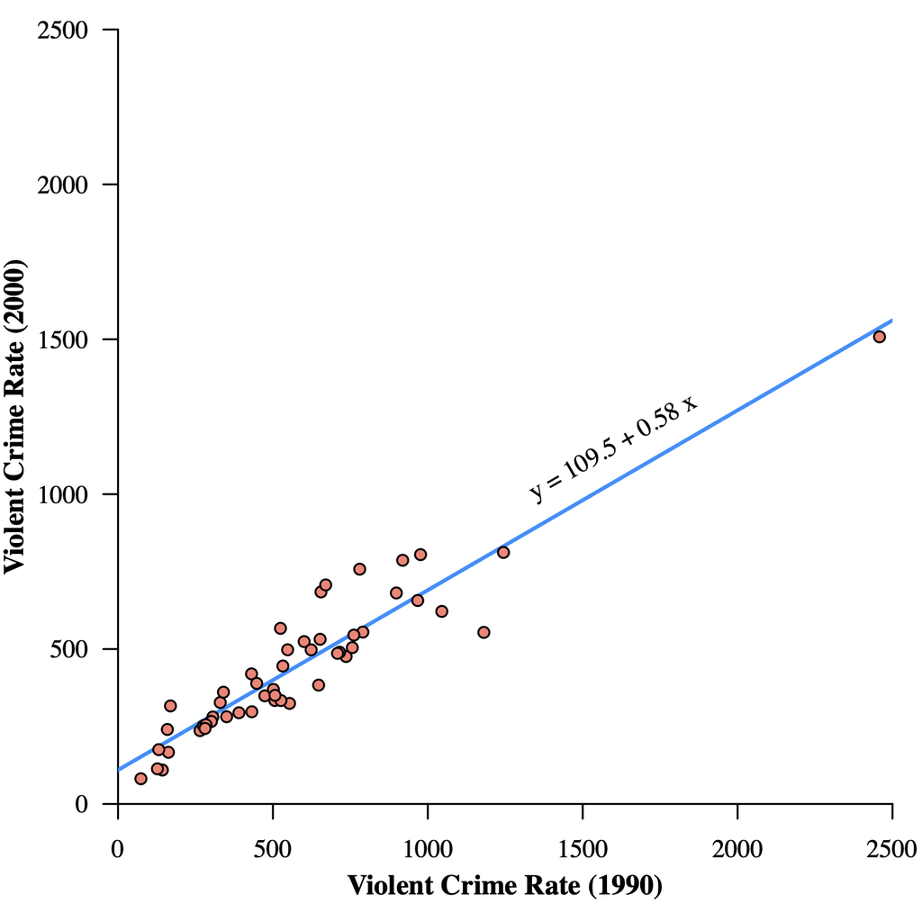

## Example #1: Violent Crime Rate in 1990 vs. 2000

The previous code provides the point estimates for the intercept and slope. However, as we already know, we also need a confidence interval to communicate the precision of our estimates.

```r
confint(modOLS)
```

```
                 2.5 %      97.5 %
(Intercept) 66.4684173 152.5859064
vcrime90     0.5182157   0.6430849
```

**Partial Conclusion:**

We are 95% confident that the true effect of the 1990 violent crime rate on the 200 violent crime rate is between 0.518 and 0.643.

## Example #1: Violent Crime Rate in 1990 vs. 2000

Since we can estimate a value of the dependent variable, we also need to calculate a confidence interval to indicate the precision of our estimate. Recall that the original problem had us estimate the 2000 violent crime rate for a state with a 1990 violent crime rate of 1500.

```r
predict(modOLS, newdata=data.frame(vcrime=1500), interval="confidence")
```

```
         fit       lwr       upr
1   537.0600  510.8882  563.2318
2   301.1418  272.7264  329.5571
3   313.1032  285.3497  340.8566
4   192.6763  156.6817  228.6709
5   360.3100  334.7013  385.9187
6   431.0332  406.9339  455.1326
7   485.5563  461.0229  510.0897
8   458.4399  434.2988  482.5811
9   359.7874  334.1595  385.4154
10  403.4524  379.0335  427.8712
11  384.6973  359.8605  409.5342
12  671.2483  636.7591  705.7374
13  568.4732  540.8010  596.1453
14  207.8313  173.0311  242.6315
```

[output cut: 37 more lines]

## Example #1: Violent Crime Rate in 1990 vs. 2000

**Partial Conclusion:**

## Example #1: Violent Crime Rate in 1990 vs. 2000

Finally, we can predict a value of the dependent variable for the next state with that value of the independent variable.

```r
predict(modOLS, newdata=data.frame(vcrime=1500), interval="prediction")
```

```
         fit         lwr       upr
1   537.0600  363.165289  710.9547
2   301.1418  126.895283  475.3882
3   313.1032  138.963404  487.2429
4   192.6763   17.034563  368.3180
5   360.3100  186.499189  534.1209
6   431.0332  257.438367  604.6281
7   485.5563  311.900640  659.2120
8   458.4399  284.839247  632.0406
9   359.7874  185.973771  533.6011
10  403.4524  229.812831  577.0919
11  384.6973  210.998548  558.3961
12  671.2483  495.908875  846.5877
13  568.4732  394.346345  742.6000
14  207.8313   32.430415  383.2321
```

[output cut: 37 more lines]

## Example #1: Violent Crime Rate in 1990 vs. 2000

**Partial Conclusion:**

## Example #1: Violent Crime Rate in 1990 vs. 2000

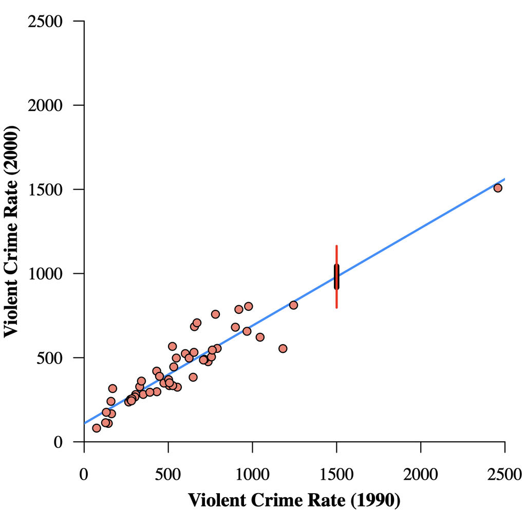

## Example #2: Violent Crime against Education

What is the relationship between the violent crime rate in 2000 and the school enrollment in 1990?

The code for this analysis:

```r
mod1 = lm(vcrime00 ~ enroll90)
summary(mod1)
```

```
Call:
lm(formula = vcrime00 ~ enroll90)

Residuals:
    Min      1Q  Median      3Q     Max
-406.58 -160.05  -55.30   98.19 1005.73

Coefficients:
            Estimate Std. Error t value Pr(>|t|)
(Intercept) -211.613    804.596  -0.263    0.794
enroll90       7.095      8.732   0.813    0.420

Residual standard error: 242.3 on 49 degrees of freedom
Multiple R-squared:  0.01329,   Adjusted R-squared:  -0.006843
F-statistic: 0.6602 on 1 and 49 DF,  p-value: 0.4204
```

**Brief Conclusion:**

Because the $p$-value of 0.4204 is greater than our usual $\alpha = 0.05$, we cannot reject the null hypothesis. We did not detect a statistically significant relationship between the school enrollment in 1990 with the violent crime rate in 2000.

## Example #3: Violent Crime against Wealth

What is the relationship between the violent crime rate in 2000 and average wealth of the state in 1990? Also, what is the predicted 2000 violent crime rate for a state with average weatlh $50,000?

## Example #3: Violent Crime against Wealth

The code for this analysis:

```r
mod2 = lm(vcrime00 ~ gspcap90)
summary(mod2)
```

```
Call:
lm(formula = vcrime00 ~ gspcap90)

Residuals:
   Min     1Q Median     3Q    Max
-413.6 -123.9  -44.5  126.1  427.8

Coefficients:
            Estimate Std. Error t value Pr(>|t|)
(Intercept) 74.32013   88.97655   0.835    0.408
gspcap90     0.01598    0.00366   4.365 6.55e-05 ***
---
Signif. codes:  0 '***' 0.001 '**' 0.01 '*' 0.05 '.' 0.1 ' ' 1

Residual standard error: 207 on 49 degrees of freedom
Multiple R-squared:   0.28, Adjusted R-squared:  0.2653
F-statistic: 19.06 on 1 and 49 DF,  p-value: 6.545e-05
```

## Example #3: Violent Crime against Wealth

The code for this analysis:

```r
confint(mod2)
```

```
                    2.5 %       97.5 %
(Intercept) -1.044849e+02 253.12520261
gspcap90     8.622233e-03   0.02333281
```

```r
predict(mod2, newdata=data.frame(gspcap90=50000), interval="prediction")
```

```
       fit      lwr      upr
1 873.1962 408.6089 1337.784
```

## Example #3: Violent Crime against Wealth

**Brief Conclusion:**

Because the $p$-value is much less than our usual $\alpha = 0.05$, we can reject the null hypothesis. We did detect a statistically significant relationship between the state’s average wealth in 1990 with the violent crime rate in 2000.

For every $1,000 increase in average wealth in the state, the 2000 violent crime rate increase by an average of between 8.6 and 23.3.

We predict that a state with a GSP per capita of $50,000 in 1990 will have a violent crime rate in 2000 between 409 and 1338, with a prediction of 873.

## Example #4: Violent Crime against the Unemployment Rate

What is the relationship between the violent crime rate in 2000 and the unemployment rate in 1990? If there is a relationship, estimate the 2000 violent crime rate given the 1990 unemployment rate is 10%.

## Example #4: Violent Crime against the Unemployment Rate

The code for this analysis:

```r
mod3 = lm(vcrime00 ~ unemp1990)
summary(mod3)
```

```
Call:
lm(formula = vcrime00 ~ unemp1990)

Residuals:
    Min      1Q  Median      3Q     Max
-346.28 -146.21  -53.13   91.02 1035.79

Coefficients:
            Estimate Std. Error t value Pr(>|t|)
(Intercept)   293.51     168.04   1.747    0.087 .
unemp1990      27.06      30.09   0.899    0.373
---
Signif. codes:  0 '***' 0.001 '**' 0.01 '*' 0.05 '.' 0.1 ' ' 1

Residual standard error: 241.9 on 49 degrees of freedom
Multiple R-squared:  0.01624,   Adjusted R-squared:  -0.003835
F-statistic: 0.809 on 1 and 49 DF,  p-value: 0.3728
```

**Interpretation:**

Because the $p$-value of 0.373 is greater than out usual $\alpha = 0.05$, we cannot reject the null hypothesis. We did not detect a statistically significant relationship between the unemployment rate in 1990 with the violent crime rate in 2000.

## Beyond Simple Linear Regression

The previous example had one numeric dependent variable and *one* numeric independent variable, hence **Simple Linear Regression**. However, research usually posits that multiple variables affect the variable of interest (response variable). For example:

- state wealth depends on political, economic, and geographical factors.
- propensity for terrorist activity depends on minority concentration, economic strengths, and past activity.
- football power depends on the quality of the quarterback, the quality of the league, and the quality of the coach.
- success probability in STAT 200 depends on professor, preparation, study habits, and events happening in your life.

Nothing we have discussed so far can handle this many independent variables.

## Violent Crime vs. Urban Percent *and Region*

As a part of her research, a former Knox student hypothesized that there was a relationship between the violent crime rate and the percent of the population that is urban. She also hypothesized that this relationship differed across the four census regions.

Her actual research focused on policing policies across the United States and their effects on crime rate. This statistical work was just a small part of her effort. In fact, it was a very small part once she had the data.

From her literature review, she further hypothesized that there was a positive relationship between the violent crime rate and the urban percent, and that the relationship would be strongest in the Southern census region of the United States.

## Violent Crime vs. Urban Percent *and Region*

The code for the *first* part of this analysis is:

```r
mod1 = lm(vcrime00 ~ urbanp1990 * census4)
summary.aov(mod1)
```

```
                   Df  Sum Sq Mean Sq F value   Pr(>F)
urbanp1990          1  178031  178031   5.402   0.0249 *
census4             3  950724  316908   9.615 5.61e-05 ***
urbanp1990:census4  3  368879  122960   3.731   0.0181 *
Residuals          43 1417204   32958
---
Signif. codes:  0 '***' 0.001 '**' 0.01 '*' 0.05 '.' 0.1 ' ' 1
```

Why `summary.aov`? There is a categorical independent variable and we want to determine if the *variable* and/or its *interaction* is important.

## Violent Crime vs. Urban Percent *and Region*

Note that the interaction between the two variables is significant ($p= 0.0181 < 0.05 = \alpha$). As such, both variables are important in the understanding of the violent crime rate in 2000 (in this model).

Furthermore, this result supports her second hypothesis, that the effect of urbanness on the violent crime rate varies from region to region.

## Violent Crime vs. Urban Percent *and Region*

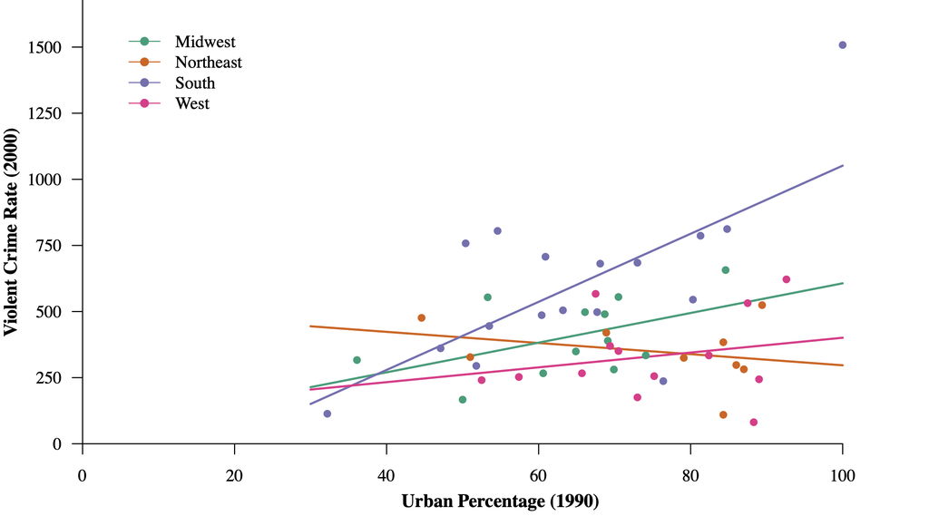

## Violent Crime vs. Urban Percent *and Region*

Because it is important to illustrate your results with specific examples, let us *estimate* the 2000 violent crime rate for a specific southern state with an urban population of 90%:

```r
predict(mod1,
        data.frame(urbanp1990=90, census4="South"),
        interval="confidence")
```

```
       fit      lwr      upr
1 922.8865 758.8959 1086.877
```

From these results, a 95% confidence interval for the 2000 violent crime rate for a southern state with a 90% urban population is from 759 to 1087, with a point estimate of 923 violent crimes per 100,000 people.

## Violent Crime vs. Urban Percent *and Region*

Again, because it is important to illustrate your results with specific examples, let us predict the 2000 violent crime rate for a southern state with an urban population of 90%:

```r
predict(mod1,
        data.frame(urbanp1990=90, census4="South"),
        interval="predict")
```

```
       fit      lwr      upr
1 922.8865 521.7188 1324.054
```

From these results, a 95% prediction interval for the 2000 violent crime rate for a southern state with a 90% urban population is from 522 to 1324, with a point estimate of 923 violent crimes per 100,000 people.

## Violent Crime vs. Property Crime and Region

What is the relationship between the 2000 violent crime rate and the 1990 property crime rate, when controlling for the four census regions?

## Violent Crime vs. Property Crime and Region

The code for the *first* part of this analysis is:

```r
mod2 = lm(vcrime00 ~ pcrime90 * census4)
summary.aov(mod2)
```

```
                 Df  Sum Sq Mean Sq F value   Pr(>F)
pcrime90          1 1322873 1322873  52.352 5.88e-09 ***
census4           3  423136  141045   5.582  0.00252 **
pcrime90:census4  3   82263   27421   1.085  0.36556
Residuals        43 1086565   25269
---
Signif. codes:  0 '***' 0.001 '**' 0.01 '*' 0.05 '.' 0.1 ' ' 1
```

Note that the interaction between the two variables is not statistically significant ($p= 0.36556 > 0.05 = \alpha$). As such, we need to modify our model by removing this interaction.

This decision arises from **Occam’s Razor**: All things being equal, the simpler model is the more useful. This translates as one should *generally* remove non-significant variables.

## Violent Crime vs. Property Crime and Region

This leads to the following model:

```r
mod2a = lm(vcrime00 ~ pcrime90 + census4)
summary.aov(mod2a)
```

```
            Df  Sum Sq Mean Sq F value   Pr(>F)
pcrime90     1 1322873 1322873  52.063 4.33e-09 ***
census4      3  423136  141045   5.551  0.00245 **
Residuals   46 1168828   25409
---
Signif. codes:  0 '***' 0.001 '**' 0.01 '*' 0.05 '.' 0.1 ' ' 1
```

Both variables have a detectable effect. As such, this is our model.

## Violent Crime vs. Property Crime and Region

```r
summary.lm(mod2a)
```

```
Call:
lm(formula = vcrime00 ~ pcrime90 + census4)

Residuals:
    Min      1Q  Median      3Q     Max
-364.84  -84.29  -15.69   62.73  500.83

Coefficients:
                   Estimate Std. Error t value Pr(>|t|)
(Intercept)      -143.37481   96.65541  -1.483   0.1448
pcrime90            0.12889    0.01999   6.448 6.15e-08 ***
census4Northeast  -67.79721   70.31720  -0.964   0.3400
census4South       78.62681   62.83648   1.251   0.2172
census4West      -155.24230   65.02444  -2.387   0.0211 *
---
Signif. codes:  0 '***' 0.001 '**' 0.01 '*' 0.05 '.' 0.1 ' ' 1

Residual standard error: 159.4 on 46 degrees of freedom
Multiple R-squared:  0.599, Adjusted R-squared:  0.5641
F-statistic: 17.18 on 4 and 46 DF,  p-value: 1.101e-08
```

**Again:** Note that only three of the four regions are listed here. This is because all of the effects (estimates) are measured with respect to this “base” category (Midwest). Thus, for instance, the region effect of the South is 78.63 greater than for the Midwest.

## Violent Crime vs. Property Crime and Region

The following is a graphic of the relationships between the property and the violent crime rate across the four census regions.

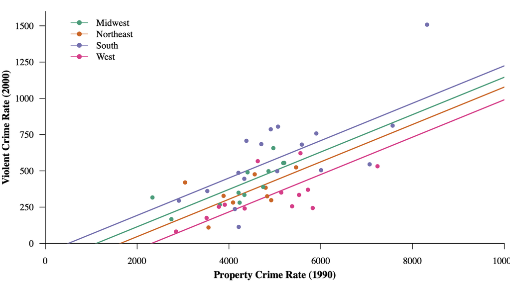

## Violent Crime vs. Property Crime and Education Level

What is the relationship between the 2000 violent crime rate and the 1990 property crime rate, when controlling for the level of education level of the state?

Note that this is a very different analysis than the previous ones. The two independent variables are *both* numeric. The analysis will be very similar, but the graphic will be quite different.

## Violent Crime vs. Property Crime and Education Level

The ANOVA output for this model is:

```r
mod3 = lm(vcrime00 ~ pcrime90 * waea90)
summary.aov(mod3)
```

```
                Df  Sum Sq Mean Sq F value   Pr(>F)
pcrime90         1 1322873 1322873  44.273 2.74e-08 ***
waea90           1  181846  181846   6.086   0.0173 *
pcrime90:waea90  1    5777    5777   0.193   0.6622
Residuals       47 1404342   29880
---
Signif. codes:  0 '***' 0.001 '**' 0.01 '*' 0.05 '.' 0.1 ' ' 1
```

Note that the interaction between the two variables is not statistically significant ($p= 0.6622 > 0.05 = \alpha$). As such, we need to modify our model by removing this interaction.

## Violent Crime vs. Property Crime and Education Level

This leads to the following model:

```r
mod3a = lm(vcrime00 ~ pcrime90 + waea90)
summary.aov(mod3a)
```

```
            Df  Sum Sq Mean Sq F value   Pr(>F)
pcrime90     1 1322873 1322873   45.03 2.04e-08 ***
waea90       1  181846  181846    6.19   0.0164 *
Residuals   48 1410119   29377
---
Signif. codes:  0 '***' 0.001 '**' 0.01 '*' 0.05 '.' 0.1 ' ' 1
```

Both variables have a detectable effect. As such, this is our model.

## Violent Crime vs. Property Crime and Education Level

The important parts of the regression table are:

```r
summary.lm(mod3a)
```

```
Call:
lm(formula = vcrime00 ~ pcrime90 + waea90)

Residuals:
    Min      1Q  Median      3Q     Max
-305.65  -98.89  -17.21   75.19  575.08

Coefficients:
             Estimate Std. Error t value Pr(>|t|)
(Intercept) 555.94745  321.06193   1.732   0.0898 .
pcrime90      0.14060    0.02039   6.897 1.06e-08 ***
waea90      -12.54722    5.04317  -2.488   0.0164 *
---
Signif. codes:  0 '***' 0.001 '**' 0.01 '*' 0.05 '.' 0.1 ' ' 1

Residual standard error: 171.4 on 48 degrees of freedom
Multiple R-squared:  0.5162,    Adjusted R-squared:  0.4961
F-statistic: 25.61 on 2 and 48 DF,  p-value: 2.7e-08
```

## Violent Crime vs. Property Crime and Education Level

**Interpretation:** For every increase in the property crime rate of 1 in 100,000, the violent crime rate tends to increase by 0.14 points, all things being equal. Similarly, for ever increas in the weighted average educational achievement of one point, the violent crime rate drops by 12.55 points.

## Violent Crime vs. Property Crime and Education Level

So, how do we illustrate the relationship between/among the two independent *numeric* variables and the dependent variable? It is quite difficult.

The key is to determine which variable *you want to emphasize* in your graphic. We shall designate this variable as the “$x$-variable”. Your $x$-variable will be assigned a range of values. All other variables need to be set to a specific value (or values).

## Violent Crime vs. Property Crime and Education Level

Depending on how complicated your graphic, those specific values may be means, medians, or quartiles. This is where a conversation with others (and experience) is very useful. Remember that education is also a *community activity*. The best work is done with others.

Also, this is where acknowledging “good” is good enough is helpful. No graphic is perfect. They are (usually) good enough. They always have weaknesses, especially because different people look for different features in a graphic.

## Violent Crime vs. Property Crime and Education Level

The following is a graphic of the relationships between the weighted average educational achievement and the violent crime rate for three exemplar property crime rates.

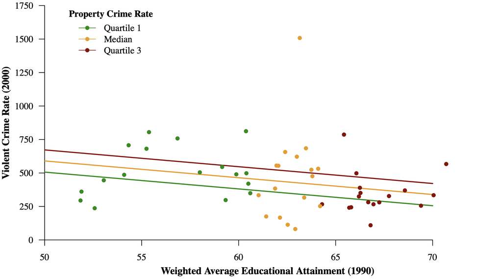

## Beyond STAT 200

At this point in the course, we are *technically* able to model a Normally-distributed response variableand that’s all. In the future, you may wish to model dependent variables that are not Normal, that are:

- just successes or failures (Bernoulli).
- counts of successes over a specified number of trials (Binomial).
- counts of successes over a specified time or region (Poisson).

These are covered in STAT 225. Here are some results you will be able to perform by the end of *that* course.

## Dichotomous (Bernoulli) Response

The following is a graphic of the relationship between a homeowner’s age and the likelihood that the homeowner has purchased flood insurance.

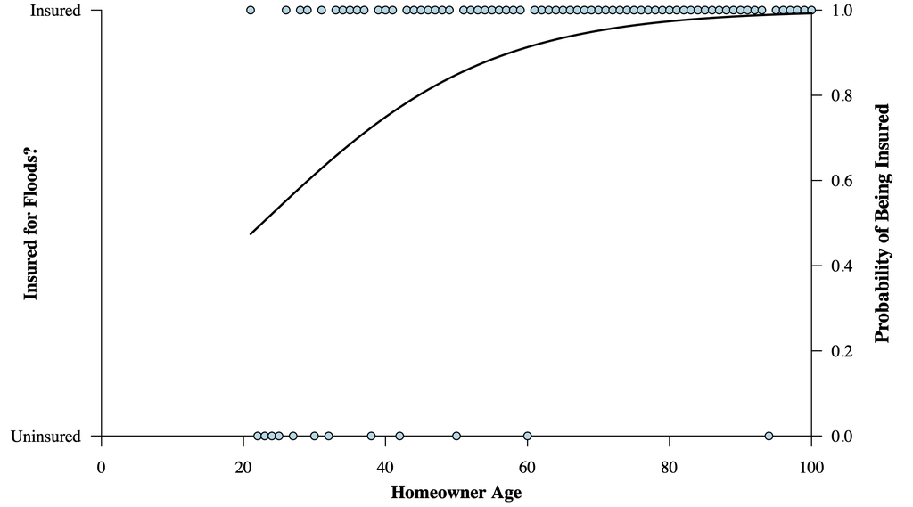

## Binomial Response

The following is a graphic of the relationship between a vote and the likelihood it was invalidated in the 2011 presidential election in Uganda.

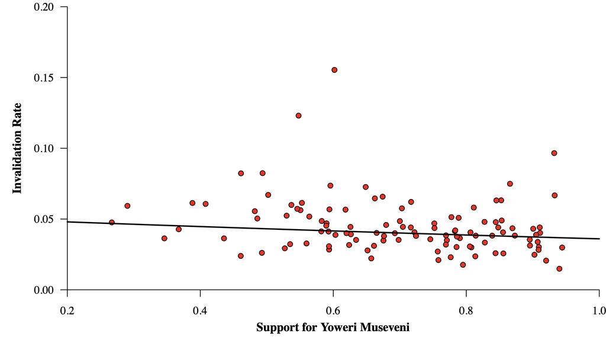

## Count (Rate) Response

The following is a graphic estimating the number of citizen’s initiatives in states based on their population and geographic region (for states that allow the initiative).

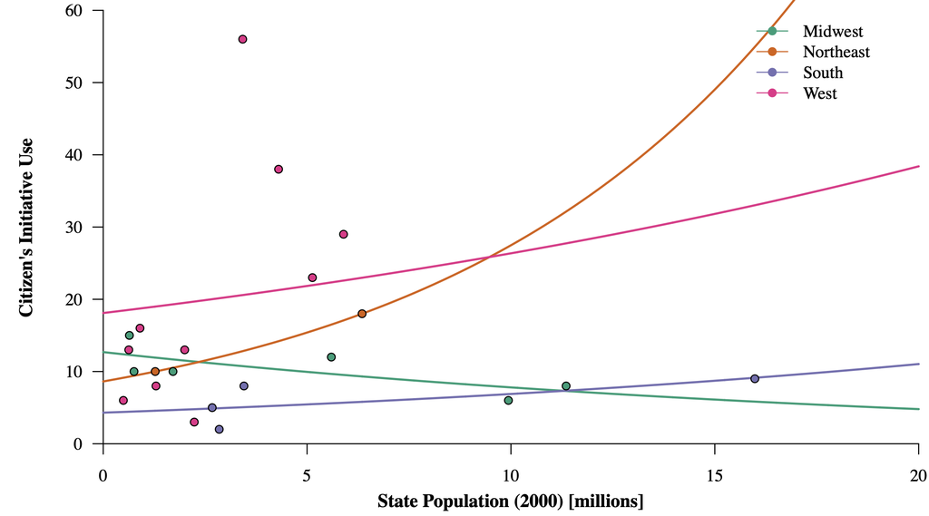